# NARFD example

Using artificial data

This document includes a brief illustration of the NARFD method for “artificial” simulated data, generated using sine and cosine functional prototypes in a way that is similar to the full simulation exercise in the manuscript.

## Example data

Observations are included in `./data/artificial_example.csv`. These data are imported and plotted in the code chunk below.

```r
artificial_df =
  read_csv(here::here("data", "artificial_example.csv"))
```

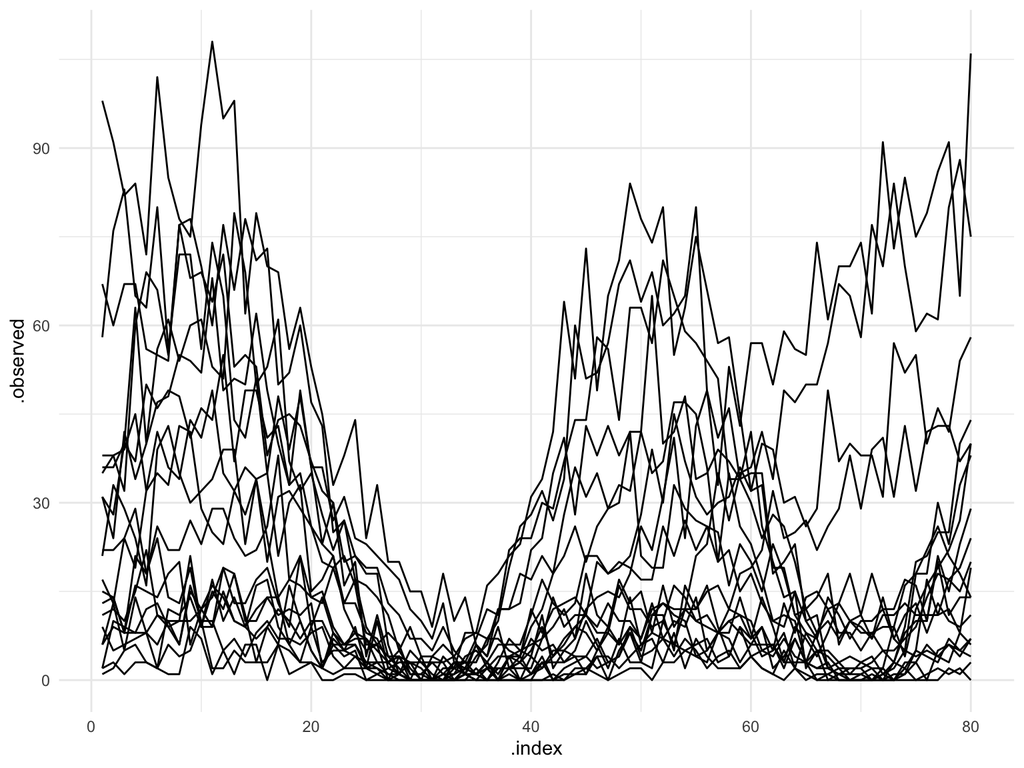

```r
artificial_df %>%
  ggplot(aes(x = .index, y = .observed, group = .id)) +
  geom_line()
```

These were generated using the code in the next chunk and exported to a csv file. The `Simulate()` function produces a list that includes observed data as well as true prototypes, scores, and latent means. The `MakeLong()` function extracts only observed data and converts this to a long-form dataframe suitable for fitting.

```r
source(here::here("source", "Simulate_Data.R"))
set.seed(1)

artificial_data <- Simulate(N = 20, D = 80, type = "NARFD", seed = 1)
artificial_df <- MakeLong(artificial_data$observations)
```

## Fit NARFD

Next we fit the proposed method using the `NARFD()` function and a pre-specified penalty sequence. In other settings, a wider range of potential penalty terms and larger number of CV folds may be more appropriate.

```r
penalty.seq <- c(0.1, 1, 10)

narfd_results <-
  NARFD(long = artificial_df, npc = 2, D = 80, type = "NARFD", nbasis = 20,
        periodic = FALSE, folds = 3, iter = 25, penalty.seq = penalty.seq)
```

The plot below shows estimated functional prototypes.

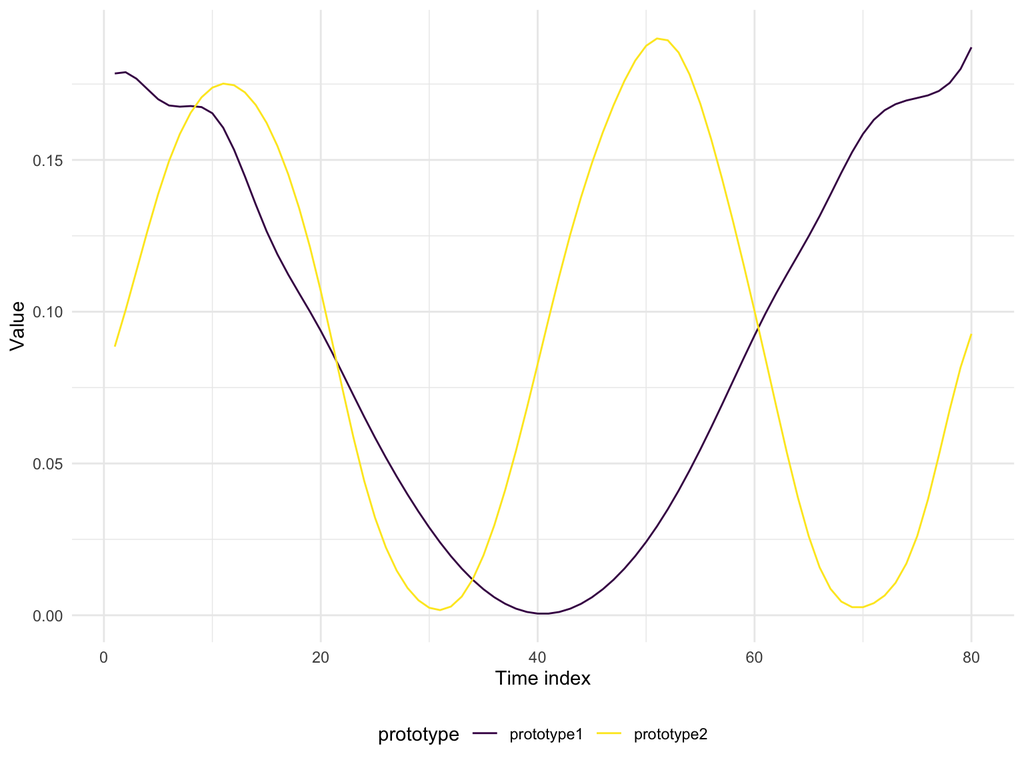

```r
narfd_results$prototypes %>%
  ggplot(aes(x = .index, y = Value, col = prototype)) +
  geom_line() +
  xlab("Time index")
```

Finally we show the observed data and fitted value for one subject.

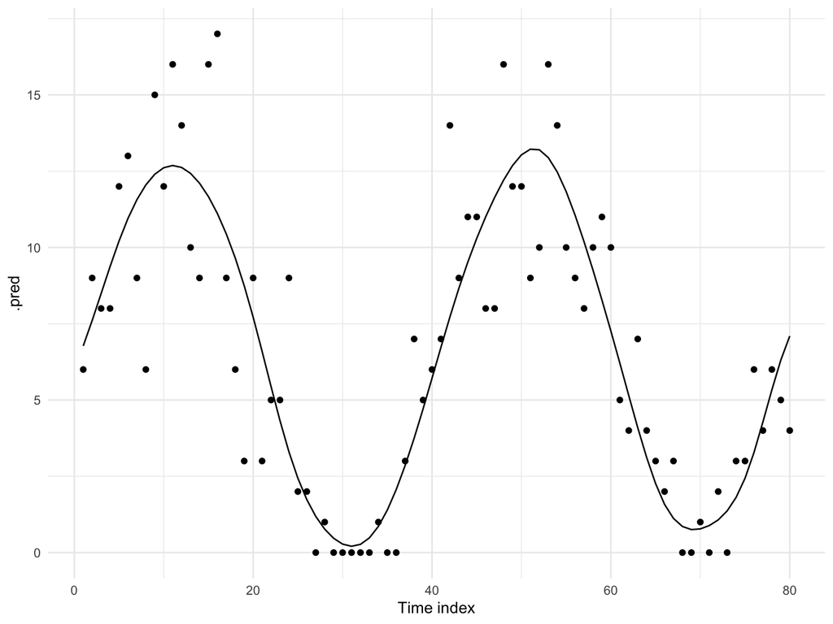

```r
narfd_results$pred %>%
  filter(.id == "IV1") %>%
  ggplot(aes(x = .index, y = .pred)) +
  geom_line() +
  geom_point(aes(y = .observed)) +
  xlab("Time index")
```